## Practical Machine Learning – Coursera Course Final Project

MZ

## Background

Using devices such as Jawbone Up, Nike FuelBand, and Fitbit it is now possible to collect a large amount of data about personal activity relatively inexpensively. These type of devices are part of the quantified self movement - a group of enthusiasts who take measurements about themselves regularly to improve their health, to find patterns in their behavior, or because they are tech geeks. One thing that people regularly do is quantify how much of a particular activity they do, but they rarely quantify how well they do it. In this project, your goal will be to use data from accelerometers on the belt, forearm, arm, and dumbell of 6 participants. They were asked to perform barbell lifts correctly and incorrectly in 5 different ways. More information is available from the website here: http://groupware.les.inf.puc-rio.br/har (see the section on the Weight Lifting Exercise Dataset).

## 1. Exploring the data:

```r
setwd("C:\\users\\zhuangmg\\coursera\\Practical Machine Learning\\project1")
training<-read.csv("pml-training.csv")
testing<-read.csv("pml-testing.csv")
dim(training)
```

```
## [1] 19622   160
```

```r
dim(testing)
```

```
## [1]  20 160
```

```r
str(training$classe)
```

```
##  Factor w/ 5 levels "A","B","C","D",..: 1 1 1 1 1 1 1 1 1 1 ...
```

```r
summary(training$classe)
```

```
##    A    B    C    D    E
## 5580 3797 3422 3216 3607
```

```r
sum(is.na(training$classe))
```

```
## [1] 0
```

There are 19622 records with 160 variables in the training dataset.Threre are five different excercise manners, which are symbolized as A, B, C, D, and E. There is no missing values for classe in the training dataset.

## 2. Cleaning the data:

First, we will remove near zero variables and columns with a lot of NA.

```r
library(caret)
nzv <- nearZeroVar(training, saveMetrics=TRUE)
training <- training[,nzv$nzv==FALSE]
dim(training)
```

```
## [1] 19622   100
```

60 variables have been removed. Now, remove variables have more than 50% missing values and variables that are only subject information.

```r
wcolrm<-which(colSums(is.na(training))>(19622/2))
training=training[,-c(wcolrm)]
dim(training)
```

```
## [1] 19622    59
```

```r
summary(training[,1:6])
```

```
##        X            user_name    raw_timestamp_part_1 raw_timestamp_part_2
##  Min.   :    1   adelmo  :3892   Min.   :1.322e+09    Min.   :   294
##  1st Qu.: 4906   carlitos:3112   1st Qu.:1.323e+09    1st Qu.:252912
##  Median : 9812   charles :3536   Median :1.323e+09    Median :496380
##  Mean   : 9812   eurico  :3070   Mean   :1.323e+09    Mean   :500656
##  3rd Qu.:14717   jeremy  :3402   3rd Qu.:1.323e+09    3rd Qu.:751891
##  Max.   :19622   pedro   :2610   Max.   :1.323e+09    Max.   :998801
##
##           cvtd_timestamp    num_window
##  28/11/2011 14:14: 1498   Min.   :  1.0
##  05/12/2011 11:24: 1497   1st Qu.:222.0
##  30/11/2011 17:11: 1440   Median :424.0
##  05/12/2011 11:25: 1425   Mean   :430.6
##  02/12/2011 14:57: 1380   3rd Qu.:644.0
##  02/12/2011 13:34: 1375   Max.   :864.0
##  (Other)         :11007
```

```r
training=training[,-c(1:6)]
dim(training)
```

```
## [1] 19622    53
```

```r
set.seed(12345)
library(caret)
inTrain = createDataPartition(y=training$classe, p=0.6, list=FALSE)
mytraining = training[inTrain,]
mytesting = training[-inTrain,]
dim(mytraining)
```

```
## [1] 11776    53
```

```r
dim(mytesting)
```

```
## [1] 7846   53
```

## 3. Building models::

We will use decision tree(model2) and random forest(model3) methods to build the model for prediction.

```r
set.seed(12345)
library(rattle)
library(rpart)
model1 <- rpart(classe~., data=mytraining, method="class")
varImp(model1)
```

```
##                         Overall
## accel_arm_x           415.30800
## accel_belt_z          625.59695
## accel_dumbbell_x     1033.31529
## accel_dumbbell_y      983.67000
## accel_dumbbell_z      105.20949
## accel_forearm_x       213.45867
## accel_forearm_z       273.37198
## gyros_belt_z          339.95222
## magnet_arm_x          333.50580
## magnet_arm_y          175.08883
## magnet_belt_x         153.41649
## magnet_belt_y        1159.51192
## magnet_belt_z         356.32533
## magnet_dumbbell_x    1075.04172
## magnet_dumbbell_y    1952.03242
## magnet_dumbbell_z     849.93623
## magnet_forearm_x      292.45679
## magnet_forearm_y       75.25799
## magnet_forearm_z      298.92824
## pitch_belt            488.98348
## pitch_dumbbell        124.54658
## pitch_forearm        1380.70101
## roll_belt            2493.71731
## roll_dumbbell         928.73385
## roll_forearm         1143.05050
## total_accel_belt      443.01903
## total_accel_dumbbell  368.47953
## yaw_arm               142.02104
## yaw_belt              287.49662
## yaw_dumbbell           94.91161
## yaw_forearm           184.24730
## gyros_belt_x            0.00000
## gyros_belt_y            0.00000
## accel_belt_x            0.00000
## accel_belt_y            0.00000
## roll_arm                0.00000
## pitch_arm               0.00000
## total_accel_arm         0.00000
## gyros_arm_x             0.00000
## gyros_arm_y             0.00000
## gyros_arm_z             0.00000
## accel_arm_y             0.00000
## accel_arm_z             0.00000
## magnet_arm_z            0.00000
## gyros_dumbbell_x        0.00000
## gyros_dumbbell_y        0.00000
## gyros_dumbbell_z        0.00000
## total_accel_forearm     0.00000
## gyros_forearm_x         0.00000
## gyros_forearm_y         0.00000
## gyros_forearm_z         0.00000
## accel_forearm_y         0.00000
```

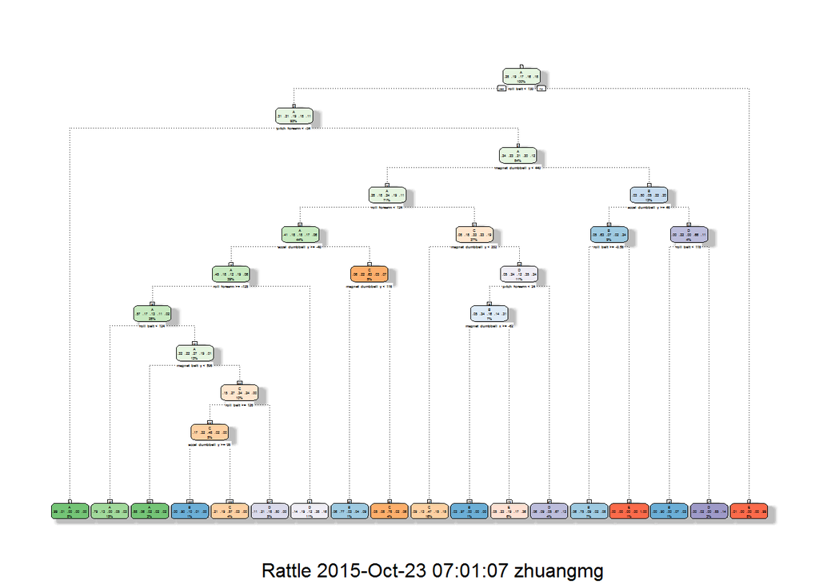

```r
# I find the eight most important variables through a simple model and build the later models based on those eight variables.
model2 <- rpart(classe~roll_belt+magnet_dumbbell_y+pitch_forearm+magnet_belt_y+roll_forearm+magnet_dumbbell_x+accel_dumbbell_y+accel_dumbbell_x, data=mytraining, method="class")
fancyRpartPlot(model2)
```

```r
set.seed(12345)
library(caret)
library(randomForest)
model3 <- randomForest(classe~roll_belt+magnet_dumbbell_y+pitch_forearm+magnet_belt_y+roll_forearm+magnet_dumbbell_x+accel_dumbbell_y+accel_dumbbell_x, data=mytraining, type="class", prox=T, importance=T)
model3
```

```
##
## Call:
##  randomForest(formula = classe ~ roll_belt + magnet_dumbbell_y +      pitch_forearm + magnet_belt_y + roll_forearm + magnet_dumbbell_x +      accel_dumbbell_y + accel_dumbbell_x, data = mytraining, type = "class",      prox = T, importance = T)
##                Type of random forest: classification
##                      Number of trees: 500
## No. of variables tried at each split: 2
##
##         OOB estimate of  error rate: 5.5%
## Confusion matrix:
##      A    B    C    D    E class.error
## A 3281   28   20   19    0  0.02001195
## B   64 1993  132   86    4  0.12549364
## C    9   41 1948   51    5  0.05160662
## D   19   28   88 1792    3  0.07150259
## E    1   14   22   14 2114  0.02355658
```

```r
cm1<-confusionMatrix(predict(model2,data=mytesting), mytestning$classe)
cm2<-confusionMatrix(predict(model3,data=mytesting), mytesting$classe)
```

Predict testing results using random forest model:

```r
pred<-predict(model3,testing)
pml_write_files = function(x){
    n = length(x)
    for(i in 1:n){
        filename = paste0("problem_id_",i,".txt")
        write.table(x[i],file=filename,quote=FALSE,row.names=FALSE,col.names=FALSE)
    }
}
pml_write_files(pred)
```

[output not shown]